# PART A

# PART B

### Domain: Optical Character Recognition (OCR)

### Context:

Recognising multi-digit numbers in photographs captured at street level is an important component of modern-day map making. A classic example of a corpus of such street-level photographs is Google’s Street View imagery composed of hundreds of millions of geo-located 360-degree panoramic images.

The ability to automatically transcribe an address number from a geo-located patch of pixels and associate the transcribed number with a known street address helps pinpoint, with a high degree of accuracy, the location of the building it represents.

More broadly, recognizing numbers in photographs is a problem of interest to the optical character recognition community.

While OCR on constrained domains like document processing is well studied, arbitrary multi-character text recognition in photographs is still highly challenging. This difficulty arises due to the wide variability in the visual appearance of text in the wild on account of a large range of fonts, colors, styles, orientations, and character arrangements.

The recognition problem is further complicated by environmental factors such as lighting, shadows, specularity, and occlusions as well as by image acquisition factors such as resolution, motion, and focus blurs.

In this project, we will use the dataset with images centered around a single digit (many of the images do contain some distractors at the sides). Although we are taking a sample of the data which is simpler, it is more complex than MNIST because of the distractor

### Objective

To build a digit classifier on the SVHN (Street View Housing Number) dataset.

### Data Dictionary

The SVHN is a real-world image dataset for developing machine learning and object recognition algorithms with the minimal requirement on data formatting but comes from a significantly harder, unsolved, real-world problem (recognizing digits and numbers in natural scene images). SVHN is obtained from house numbers in Google Street View images.

### Q1 A. Read the .h5 file and assign to a variable

#### Import necessary libraries

```python
import pandas as pd
import numpy as np
import seaborn as sns
import matplotlib.pyplot as plt
import h5py

from sklearn.model_selection import train_test_split
from scipy.stats import zscore
import warnings
from sklearn.metrics import confusion_matrix
from sklearn.metrics import classification_report
```

```python
#read .h5 file
hf = h5py.File('Autonomous_Vehicles_SVHN_single_grey1.h5', 'r')
hf
```

```
<HDF5 file "Autonomous_Vehicles_SVHN_single_grey1.h5" (mode r)>
```

### Q1 B.Print all the keys from the .h5 file.

```python
hf.keys()
```

```
<KeysViewHDF5 ['X_test', 'X_train', 'X_val', 'y_test', 'y_train', 'y_val']>
```

### Q1 C.Split the data into X_train, X_test, Y_train, Y_test

```python
# load the already split train, validation and test data into different data variables

X_train = hf['X_train'][:]
y_train = hf['y_train'][:]

X_val = hf['X_val'][:]
y_val = hf['y_val'][:]

X_test = hf['X_test'][:]
y_test = hf['y_test'][:]
```

### Q2 A - Print shape of all the 4 data split into x, y, train, test to verify if x & y is in sync.

```python
# Printing the shapes

print("X train set shape :", X_train.shape)
print("y train set shape :", y_train.shape, '\n')

print("X validation set shape :", X_val.shape)
print("y validation set shape :", y_val.shape, '\n')

print("X test set shape :", X_test.shape)
print("y test set shape :", y_test.shape)
```

```
X train set shape : (42000, 32, 32)
y train set shape : (42000,)

X validation set shape : (60000, 32, 32)
y validation set shape : (60000,)

X test set shape : (18000, 32, 32)
y test set shape : (18000,)
```

- The training dataset(X_train) has 42000 image records with image size of 32x32.
- The test dataset(X_test) has 18000 image records with image size of 32x32.
- y_train, y_test contain labels corresponding to the image matrix in training and testing datasets

### Q2 B. Visualise first 10 images in train data and print its corresponding labels.

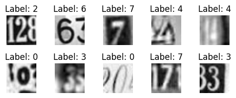

```python
# Plot the first 10 images with labels
plt.figure(figsize=(5, 5))
for i in range(10):
    plt.subplot(5, 5, i + 1)  # Create a 2-row, 5-column subplot
    plt.imshow(X_train[i], cmap='gray')  # Use cmap='gray' if images are grayscale
    plt.title(f"Label: {y_train[i]}")
    plt.axis('off')  # Turn off axes for better visualization

plt.tight_layout()
plt.show()
```

### Q2 C.Reshape all the images with appropriate shape update the data in same variable.

```python
X_train = X_train.reshape(42000, 32*32)
X_val= X_val.reshape(X_val.shape[0], 32*32)
X_test = X_test.reshape(X_test.shape[0], 32*32)

print(f'Shape of X_train is {X_train.shape}')
print(f'Shape of X_val is {X_val.shape}')
print(f'Shape of X_test is {X_test.shape}')
```

```
Shape of X_train is (42000, 1024)
Shape of X_val is (60000, 1024)
Shape of X_test is (18000, 1024)
```

### Q2 D.Normalise the images i.e. Normalise the pixel values.

```python
# Normalising the image pixels

X_test = pd.DataFrame(X_test)
X_train = pd.DataFrame(X_train)
X_val = pd.DataFrame(X_val)

# Calculate mean and standard deviation from training data
mean = X_train.mean()
std = X_train.std()

# Apply Z-score normalization
X_train_scaled = (X_train - mean) / std
X_test_scaled = (X_test - mean) / std
X_val_scaled = (X_val - mean) / std
```

```python
print('After Normalization \n')

print(f'Min value is : \n\n{X_train_scaled.min()} \n')
print(f'Max value is : \n\n{X_train_scaled.max()}')
```

```
After Normalization

Min value is :

0      -2.158445
1      -2.164119
2      -2.146456
3      -2.157172
4      -2.170006
          ...
1019   -2.119140
1020   -2.192954
1021   -2.195500
1022   -2.180591
1023   -2.174906
Length: 1024, dtype: float32

Max value is :

0       2.746868
1       2.746201
2       2.738466
3       2.730695
4       2.718812
          ...
1019    2.749713
1020    2.769422
1021    2.783717
1022    2.790547
1023    2.782414
Length: 1024, dtype: float32
```

### Q2 E.Transform Labels into format acceptable by Neural Network

```python
from keras.utils import to_categorical

y_train_new = to_categorical(y_train, num_classes=10)  #  for 10 classes
y_test_new = to_categorical(y_test, num_classes=10)
y_val_new = to_categorical(y_val, num_classes=10)

# Verify the transformation
print("y_train shape:", y_train_new.shape)
print("y_train example:", y_train_new[0])  # Check an example label after encoding
```

```
y_train shape: (42000, 10)
y_train example: [0. 0. 1. 0. 0. 0. 0. 0. 0. 0.]
```

### Q2 F. Print total Number of classes in the Dataset.

```python
y_train = pd.DataFrame(y_train)
y_test = pd.DataFrame(y_test)
y_val = pd.DataFrame(y_val)

# Concatenate the dataframes
y = pd.concat([y_train, y_val, y_test], ignore_index=True)

# Check the shape of the resulting dataframe
print(y.shape)
```

```
(120000, 1)
```

```python
print (f'List of classes in the Dataset : \n\n{y.value_counts()}\n\n')
print (f'Total number of classes in the Dataset : \n\n{y.nunique()}')
```

```
List of classes in the Dataset :

0
0    12000
1    12000
2    12000
3    12000
4    12000
5    12000
6    12000
7    12000
8    12000
9    12000
Name: count, dtype: int64


Total number of classes in the Dataset :

0    10
dtype: int64
```

### Q3 A.Design a Neural Network to train a classifier.

```python
from tensorflow.keras import optimizers, losses

# Initialize the model
model = Sequential()

# Add BatchNormalization with correct input shape
model.add(Input(shape=(1024,)))
model.add(BatchNormalization())  # BatchNormalization expects a shape, not a tuple

# Add Dense layers
model.add(Dense(256, activation='relu'))
model.add(Dense(64, activation='relu'))
model.add(Dense(32, activation='relu'))
model.add(Dense(10, activation='softmax'))  # Output layer for 10 classes (using softmax for multi-class classification)

# Compile the model
sgd = optimizers.Adam(learning_rate=1e-3)  # Corrected from 'lr' to 'learning_rate'
model.compile(loss=losses.categorical_crossentropy,
              optimizer=sgd,
              metrics=['accuracy'])

# Model summary (optional, to check the architecture)
model.summary()
```

```
Model: "sequential_43"
```

```
┏━━━━━━━━━━━━━━━━━━━━━━━━━━━━━━━━━┳━━━━━━━━━━━━━━━━━━━━━━━━┳━━━━━━━━━━━━━━━┓
┃ Layer (type)                    ┃ Output Shape           ┃       Param # ┃
┡━━━━━━━━━━━━━━━━━━━━━━━━━━━━━━━━━╇━━━━━━━━━━━━━━━━━━━━━━━━╇━━━━━━━━━━━━━━━┩
│ batch_normalization_25          │ (None, 1024)           │         4,096 │
│ (BatchNormalization)            │                        │               │
├─────────────────────────────────┼────────────────────────┼───────────────┤
│ dense_133 (Dense)               │ (None, 256)            │       262,400 │
├─────────────────────────────────┼────────────────────────┼───────────────┤
│ dense_134 (Dense)               │ (None, 64)             │        16,448 │
├─────────────────────────────────┼────────────────────────┼───────────────┤
│ dense_135 (Dense)               │ (None, 32)             │         2,080 │
├─────────────────────────────────┼────────────────────────┼───────────────┤
│ dense_136 (Dense)               │ (None, 10)             │           330 │
└─────────────────────────────────┴────────────────────────┴───────────────┘
```

```
 Total params: 285,354 (1.09 MB)
```

```
 Trainable params: 283,306 (1.08 MB)
```

```
 Non-trainable params: 2,048 (8.00 KB)
```

### Q3 B.Train the classifier using previously designed Architecture (Use best suitable parameters).

```python
# Fit the model
history = model.fit(X_train_scaled,y_train_new, validation_data=(X_val_scaled,y_val_new),epochs=30,batch_size=200,verbose=2)
scores= model.evaluate(X_test_scaled,y_test_new,verbose=0)
print(f"Error:%.2f%% %(100-scores[1]*100) \n")
print('Validation Accuracy :', scores[1])
```

```
210/210 - 5s - 22ms/step - accuracy: 0.4957 - loss: 1.5087 - val_accuracy: 0.6868 - val_loss: 1.0144
210/210 - 3s - 12ms/step - accuracy: 0.7048 - loss: 0.9468 - val_accuracy: 0.7510 - val_loss: 0.8063
210/210 - 3s - 12ms/step - accuracy: 0.7537 - loss: 0.7991 - val_accuracy: 0.7770 - val_loss: 0.7273
210/210 - 3s - 12ms/step - accuracy: 0.7815 - loss: 0.7113 - val_accuracy: 0.7957 - val_loss: 0.6714
210/210 - 3s - 15ms/step - accuracy: 0.7993 - loss: 0.6518 - val_accuracy: 0.8206 - val_loss: 0.5966
210/210 - 2s - 11ms/step - accuracy: 0.8179 - loss: 0.5951 - val_accuracy: 0.8144 - val_loss: 0.6077
210/210 - 3s - 13ms/step - accuracy: 0.8271 - loss: 0.5639 - val_accuracy: 0.8287 - val_loss: 0.5683
210/210 - 3s - 12ms/step - accuracy: 0.8343 - loss: 0.5346 - val_accuracy: 0.8392 - val_loss: 0.5358
210/210 - 3s - 12ms/step - accuracy: 0.8421 - loss: 0.5089 - val_accuracy: 0.8493 - val_loss: 0.5019
210/210 - 2s - 12ms/step - accuracy: 0.8510 - loss: 0.4798 - val_accuracy: 0.8540 - val_loss: 0.4858
210/210 - 2s - 11ms/step - accuracy: 0.8568 - loss: 0.4604 - val_accuracy: 0.8530 - val_loss: 0.4862
210/210 - 2s - 10ms/step - accuracy: 0.8610 - loss: 0.4459 - val_accuracy: 0.8615 - val_loss: 0.4673
210/210 - 2s - 9ms/step - accuracy: 0.8665 - loss: 0.4241 - val_accuracy: 0.8705 - val_loss: 0.4346
210/210 - 3s - 12ms/step - accuracy: 0.8705 - loss: 0.4140 - val_accuracy: 0.8663 - val_loss: 0.4477
210/210 - 3s - 12ms/step - accuracy: 0.8793 - loss: 0.3874 - val_accuracy: 0.8767 - val_loss: 0.4294
210/210 - 2s - 10ms/step - accuracy: 0.8793 - loss: 0.3832 - val_accuracy: 0.8670 - val_loss: 0.4478
210/210 - 2s - 10ms/step - accuracy: 0.8790 - loss: 0.3820 - val_accuracy: 0.8846 - val_loss: 0.3980
210/210 - 2s - 9ms/step - accuracy: 0.8895 - loss: 0.3561 - val_accuracy: 0.8853 - val_loss: 0.3944
210/210 - 2s - 11ms/step - accuracy: 0.8920 - loss: 0.3444 - val_accuracy: 0.8864 - val_loss: 0.3925
210/210 - 2s - 10ms/step - accuracy: 0.8956 - loss: 0.3286 - val_accuracy: 0.8869 - val_loss: 0.3891
210/210 - 2s - 11ms/step - accuracy: 0.8949 - loss: 0.3302 - val_accuracy: 0.8875 - val_loss: 0.3872
210/210 - 2s - 11ms/step - accuracy: 0.8986 - loss: 0.3213 - val_accuracy: 0.8986 - val_loss: 0.3601
210/210 - 2s - 9ms/step - accuracy: 0.9035 - loss: 0.3030 - val_accuracy: 0.8931 - val_loss: 0.3776
210/210 - 3s - 12ms/step - accuracy: 0.9030 - loss: 0.3062 - val_accuracy: 0.8970 - val_loss: 0.3679
210/210 - 2s - 9ms/step - accuracy: 0.9059 - loss: 0.2993 - val_accuracy: 0.8975 - val_loss: 0.3676
210/210 - 2s - 9ms/step - accuracy: 0.9071 - loss: 0.2880 - val_accuracy: 0.8979 - val_loss: 0.3687
210/210 - 2s - 10ms/step - accuracy: 0.9095 - loss: 0.2871 - val_accuracy: 0.8969 - val_loss: 0.3712
210/210 - 2s - 10ms/step - accuracy: 0.9083 - loss: 0.2864 - val_accuracy: 0.9020 - val_loss: 0.3527
210/210 - 2s - 10ms/step - accuracy: 0.9139 - loss: 0.2681 - val_accuracy: 0.9054 - val_loss: 0.3496
210/210 - 2s - 10ms/step - accuracy: 0.9146 - loss: 0.2649 - val_accuracy: 0.9043 - val_loss: 0.3542
Error:%.2f%% %(100-scores[1]*100)

Validation Accuracy : 0.8405555486679077
```

```python
#Prediction for First sample data displayed
y_test_pred = model.predict(X_test_scaled)
y_test_pred[0]
```

```
563/563 ━━━━━━━━━━━━━━━━━━━━ 1s 864us/step
```

```
array([0.50599277, 0.01585458, 0.01104762, 0.00171061, 0.04030904,
       0.01900882, 0.15030777, 0.00809485, 0.07995715, 0.16771667],
      dtype=float32)
```

```python
#Extract output class
y_test_pred_final = []
for i in y_test_pred:
  y_test_pred_final.append(np.argmax(i))

# Output class of sample data input 9
y_test_pred_final[9]
```

```
4
```

### Q3 C. Evaluate performance of the model with appropriate metrics.

```python
print(classification_report(y_test, y_test_pred_final))
```

```
              precision    recall  f1-score   support

           0       0.87      0.88      0.88      1814
           1       0.81      0.86      0.83      1828
           2       0.85      0.85      0.85      1803
           3       0.85      0.75      0.80      1719
           4       0.85      0.88      0.87      1812
           5       0.82      0.84      0.83      1768
           6       0.82      0.86      0.84      1832
           7       0.86      0.87      0.86      1808
           8       0.83      0.79      0.81      1812
           9       0.85      0.82      0.83      1804

    accuracy                           0.84     18000
   macro avg       0.84      0.84      0.84     18000
weighted avg       0.84      0.84      0.84     18000
```

- Class 0, 4, and 7 have the highest F1-scores (0.86–0.88), showing the model has learned to distinguish these classes effectively.
- Class 3 has the lowest F1-score (0.80), with a significant drop in recall (0.75) despite good precision (0.85). This suggests that the model misses several instances of this class (higher false negatives).
- Class 8 also shows slightly weaker performance, with an F1-score of 0.81, driven by both lower precision (0.83) and recall (0.79).
- Class 6 has Good recall (0.86) but slightly lower precision (0.82) suggests the model may occasionally misclassify other classes as 6.

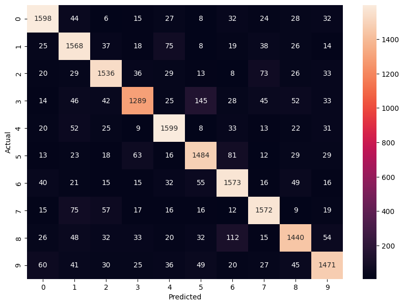

```python
# Confusion Matrix

cm = confusion_matrix(y_test,y_test_pred_final)

plt.figure(figsize=(10,7))
sns.heatmap(cm,annot=True,fmt='d')
plt.xlabel('Predicted')
plt.ylabel('Actual')
plt.show()
```

```python
# Based on the above observation, seems to be there are Misclassified Images
index = 0
misclassified_images = []
for label, predict in zip(y_test, y_test_pred_final):
    if label != predict:
        misclassified_images.append(index)
    index +=1
print("List of Misclassified Images :", misclassified_images)
print("Total number of misclassified images :", len(misclassified_images))
```

```
List of Misclassified Images : []
Total number of misclassified images : 0
```

### Q3 D.Plot the training loss, validation loss vs number of epochs and training accuracy, validation accuracy vs number of epochs plot and write your observations on the same.

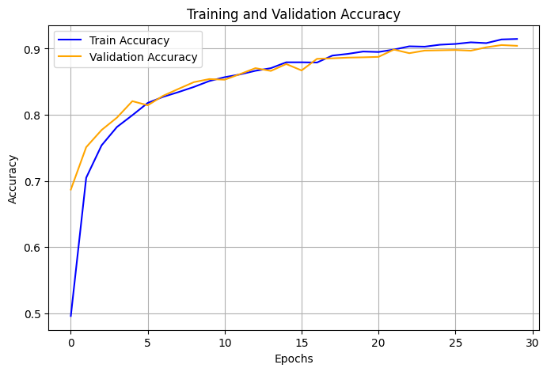

```python
# Plot validation accuracy
plt.figure(figsize=(8, 5))
plt.plot(history.history['accuracy'], label='Train Accuracy', color='blue')
plt.plot(history.history['val_accuracy'], label='Validation Accuracy', color='orange')
plt.xlabel('Epochs')
plt.ylabel('Accuracy')
plt.title('Training and Validation Accuracy')
plt.legend()
plt.grid(True)
plt.show()
```

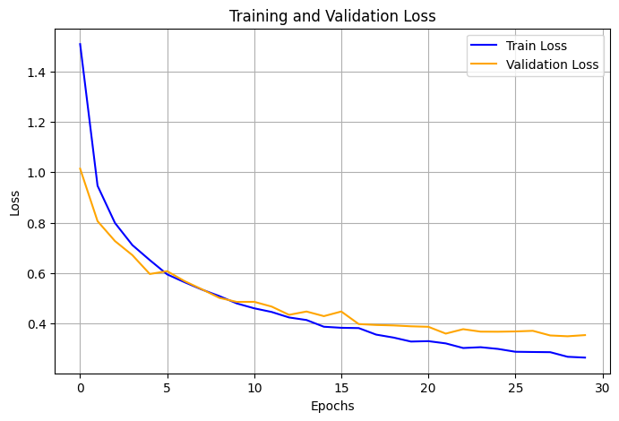

```python
# Plot loss
plt.figure(figsize=(8, 5))
plt.plot(history.history['loss'], label='Train Loss', color='blue')
plt.plot(history.history['val_loss'], label='Validation Loss', color='orange')
plt.xlabel('Epochs')
plt.ylabel('Loss')
plt.title('Training and Validation Loss')
plt.legend()
plt.grid(True)
plt.show()
```

- Training vs Validation Loss
  - Both training and validation loss decrease consistently over the epochs, indicating that the model is learning effectively.The validation loss closely follows the training loss curve, with only minor fluctuations.
  - The small gap between training and validation loss suggests that the model is generalizing well without significant overfitting.

As the epochs progress, both losses appear to plateau, signaling that the model is reaching convergence.

- Training vs Validation Accuracy
  - Both training and validation accuracy increase steadily and converge near 90% after 30 epochs. The validation accuracy shows minor fluctuations but consistently tracks closely with training accuracy.
  - The high and nearly equal accuracy for both training and validation sets indicates good model performance. No significant divergence is seen between training and validation accuracy, which further confirms the absence of overfitting.

#### Summary:

- The model demonstrates stable training and effective learning, with no major signs of overfitting or underfitting.
- The model achieves strong accuracy for both training and validation sets, suggesting it has learned the task effectively without significant issues.
- The slight plateauing of both loss and accuracy suggests the model is nearing optimal performance.